# Personal Movement Analysis using Activity Monitoring Device

## Introduction

It is now possible to collect a large amount of data about personal movement using activity monitoring devices such as a Fitbit, Nike Fuelband, or Jawbone Up.In this assignment,we will try assignment to makes use of data from a personal activity monitoring device and try answering few questions. The device collects data at 5 minute intervals through out the day. The data consists of two months of data from an anonymous individual collected during the months of October and November, 2012 and include the number of steps taken in 5 minute intervals each day.

### Loading and preprocessing the data

We will begin with the analysis by downloading the data from *here*. Unzip the zip file and extract the data from the csv file into a dataset named activity, readable in R.

```r
# set the working directory (optional)
setwd("/Users/ranjeetapegu/Documents/Coursera/Reproducible Result/week 2")
if(!file.exists("./RepAct")){dir.create("./RepAct")}
Dwurl <- "https://d396qusza40orc.cloudfront.net/repdata%2Fdata%2Factivity.zip"
download.file(url =Dwurl, destfile = "./RepAct/RepAct.zip", mode ="wb")
unzip("./RepAct/RepAct.zip", exdir = "./RepAct")
activity <- read.csv("./RepAct/activity.csv", header = TRUE, sep =",")
head(activity)
```

```
##   steps       date interval
## 1    NA 2012-10-01        0
## 2    NA 2012-10-01        5
## 3    NA 2012-10-01       10
## 4    NA 2012-10-01       15
## 5    NA 2012-10-01       20
## 6    NA 2012-10-01       25
```

**What is mean total number of steps taken per day?**  
Lets find out the mean of total number of steps taken per day, for this,the missing values in the dataset will be ignored.The total number of steps taken per day is calculated by taking the sum of steps group by the date. A histogram of the total number of steps taken each day is plotted.

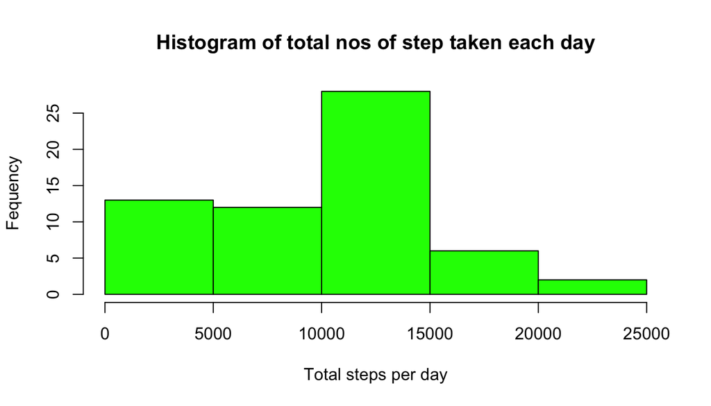

```r
Daily.step <- aggregate(activity$steps, by = list(activity$date),FUN = sum, na.rm = T)
names(Daily.step) <- c("date", "steps")
# Make a histogram of the total number steps taken
hist(Daily.step$steps, main ="Histogram of total nos of step taken each day",xlab ="Total steps per day", ylab= "Fequency",col = "green")
```

Lets find out the mean and median of the total number of steps taken per day by using the summary function.

```r
summary(Daily.step$steps)
```

```
##    Min. 1st Qu.  Median    Mean 3rd Qu.    Max.
##       0    6778   10400    9354   12810   21190
```

**What is the average daily activity pattern?**  
To find the average daily activity pattern, we will make a time series plot of the 5-minute interval (x-axis) and the average number of steps taken, averaged across all days (y-axis).The red vertical line in the plot shows the 5-minute interval (i.e. 835) which contains the maximum number of steps.

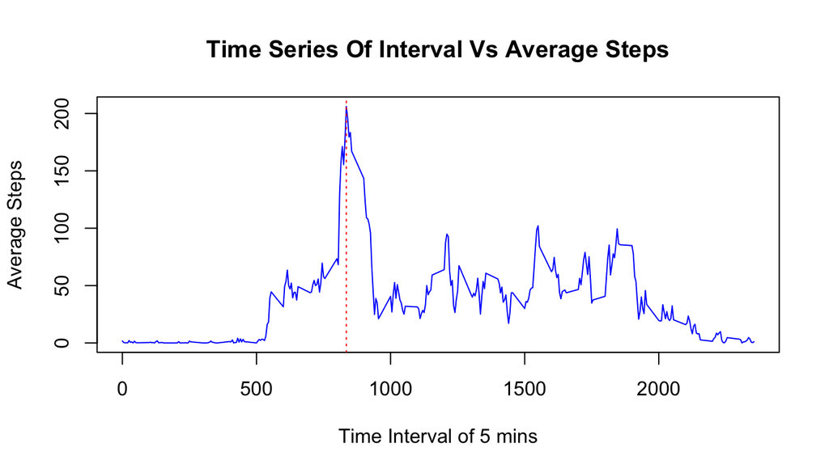

```r
Avgstep.timeIn <- aggregate(activity$steps, by = list(activity$interval),FUN = mean, na.rm = T)
names(Avgstep.timeIn) <- c("Interval","Steps")
maxstep <- Avgstep.timeIn[Avgstep.timeIn$Steps == max(Avgstep.timeIn$Steps),c(1) ]
plot( Avgstep.timeIn$Interval, Avgstep.timeIn$Steps , type ="l" , col ="blue" ,
      main ="Time Series Of Interval Vs Average Steps",
      xlab="Time Interval of 5 mins" ,
      ylab = "Average Steps")
abline(v = maxstep, lty= 3, col ="red")
```

**Imputing missing values**

There are a number of days/intervals where there are missing values coded as NA, this may introduce some bias into some calculations and summaries of the data. Lets get the total number of missing values in the dataset (i.e. the total number of rows with 𝙽𝙰s)

```r
 summary(activity$steps)
```

```
##    Min. 1st Qu.  Median    Mean 3rd Qu.    Max.    NA's
##    0.00    0.00    0.00   37.38   12.00  806.00    2304
```

We see there is a total of 2304 missig values. We will fill the missing value by mean for that 5 min interval for all days and make a new dataset names New.Activity.

```r
Avgstep.timeIn <- aggregate(activity$steps, by = list(activity$interval), FUN = mean, na.rm = T)
names(Avgstep.timeIn) <- c("interval","AvgSteps")
New.Activity <- merge(activity, Avgstep.timeIn, by ="interval")
New.Activity$steps[is.na(New.Activity$steps)] <- New.Activity$AvgSteps[is.na(New.Activity$steps)]
New.Activity$steps <-round( New.Activity$steps)
```

Lets plot a histogram of the total number of steps taken each day using the new dataset, to see the difference between the estimates from the new dataset and old dataset.

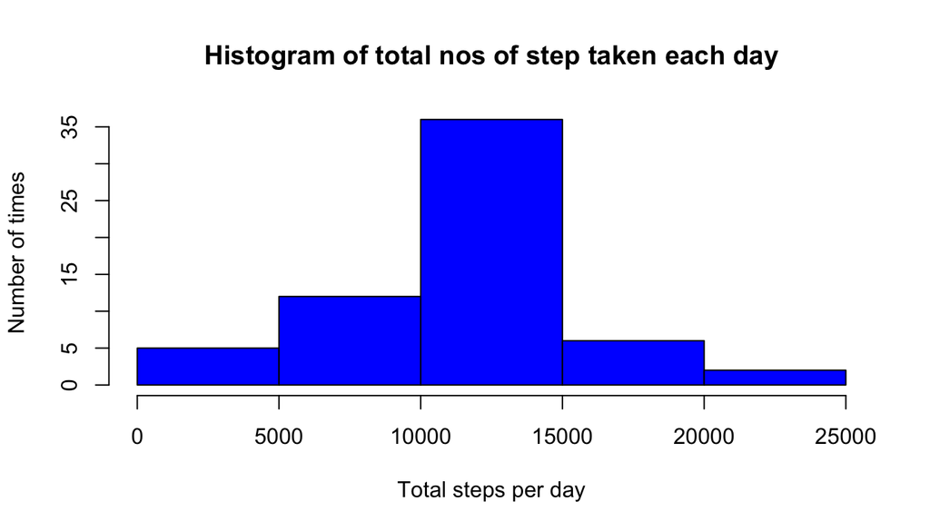

```r
NDaily.step <- aggregate(New.Activity$steps, by = list(New.Activity$date),FUN = sum,  na.rm = T)
names(NDaily.step) <- c("date", "steps")
hist(NDaily.step$steps, main ="Histogram of total nos of step taken each day",xlab ="Total steps per day", ylab= "Number of times",col = "Blue")
```

```r
summary(New.Activity$steps)
```

```
##    Min. 1st Qu.  Median    Mean 3rd Qu.    Max.
##    0.00    0.00    0.00   37.38   27.00  806.00
```

**Are there differences in activity patterns between weekdays and weekends?**  
Using the dataset with the filled-in missing values , we create a new factor variable day, two levels – “weekday” and “weekend” indicating whether a given date is a weekday or weekend day. plot charts having time series plot of the 5-minute interval (x-axis) and the average number of steps taken, averaged across all weekday days or weekend days (y-axis).

```r
New.Activity$d <- weekdays(as.Date(New.Activity$date))
New.Activity$day <-  as.factor(ifelse(New.Activity$d %in% c("Saturday","Sunday"), "Weekend","Weekday") )
head(New.Activity)
```

```
##   interval steps       date AvgSteps        d     day
## 1        0     2 2012-10-01 1.716981   Monday Weekday
## 2        0     0 2012-11-23 1.716981   Friday Weekday
## 3        0     0 2012-10-28 1.716981   Sunday Weekend
## 4        0     0 2012-11-06 1.716981  Tuesday Weekday
## 5        0     0 2012-11-24 1.716981 Saturday Weekend
## 6        0     0 2012-11-15 1.716981 Thursday Weekday
```

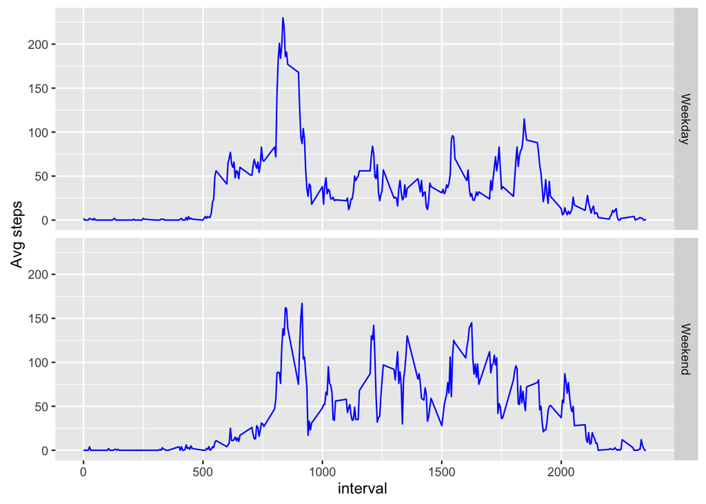

```r
Int_Avgstep <- aggregate(New.Activity$steps, by = list(New.Activity$interval,
                        New.Activity$day),FUN = mean, na.rm = T)
names(Int_Avgstep) <- c("interval","day","steps")
Int_Avgstep$steps <- round(Int_Avgstep$steps)
library(ggplot2)
ggplot(Int_Avgstep, aes(interval, steps )) + geom_line(colour = "blue") +
       xlab("interval ") + ylab ("Avg steps") + facet_grid(facets = day ~ .)
```

From the above charts we conclude that the average number of steps taken in weekdays is significantly higher in time interval between 750 -1000, whereas for weekends we did not observe such high peak during the same interval period.